# Statcast: The Revolution of Statistics in Baseball

John Nobles, Adam Gullion, Jonathan Aguilar

2025-05-06

# Introduction

-Statcast is an automated camera tool that was developed by ChyronHego, Trackman, and MLB

-It helps teams and players analyze work towards improving their athletic potential

[figure not shown]

Statcast Camera In an MLB Stadium

# More about statcast

-It was installed in all 30 MLB stadiums in 2015

-Statcast has fundamentally changed the way the game of baseball is played as it introduced statistics that changed strategy all across MLB.

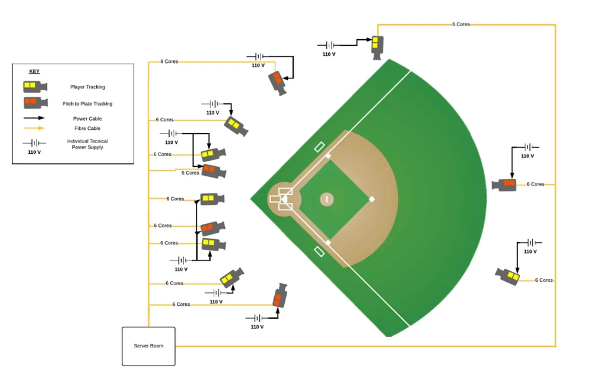

Statcast Camera Layout

[technology.mlblogs.com](https://technology.mlblogs.com/introducing-statcast-2020-hawk-eye-and-google-cloud-a5f5c20321b8)

# Explanation of woba

Before we talk about Statcast metrics about a players hitting philosphy, we need to talk about woba and xwobacon.

The stat woba stands for weighted on base average.

According to Fangraphs, a rule of thumb about woba is

-Excellent .400

-Above Average .340

-Average .320

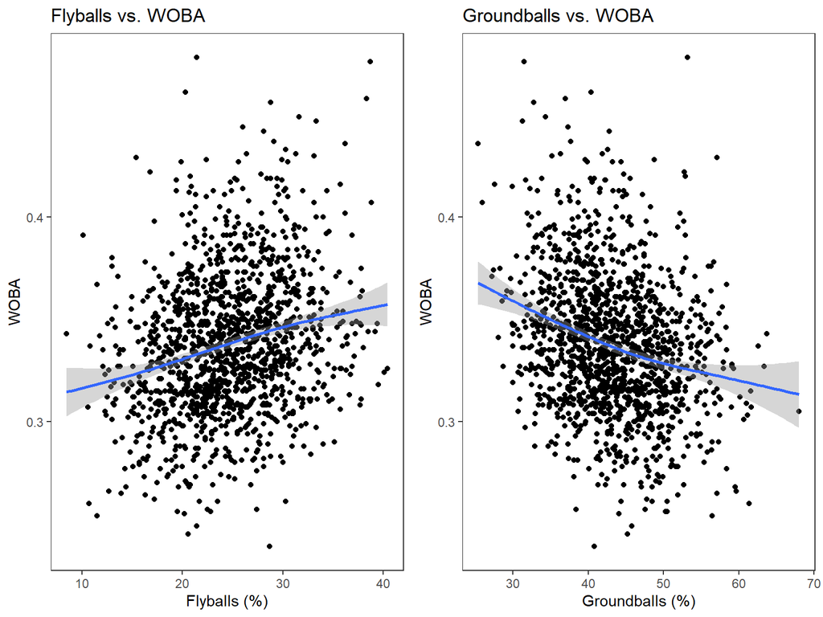

# xwobacon

The stat xwobacon stands for expected weighted on base average on contact. Think of it as the potential stat.

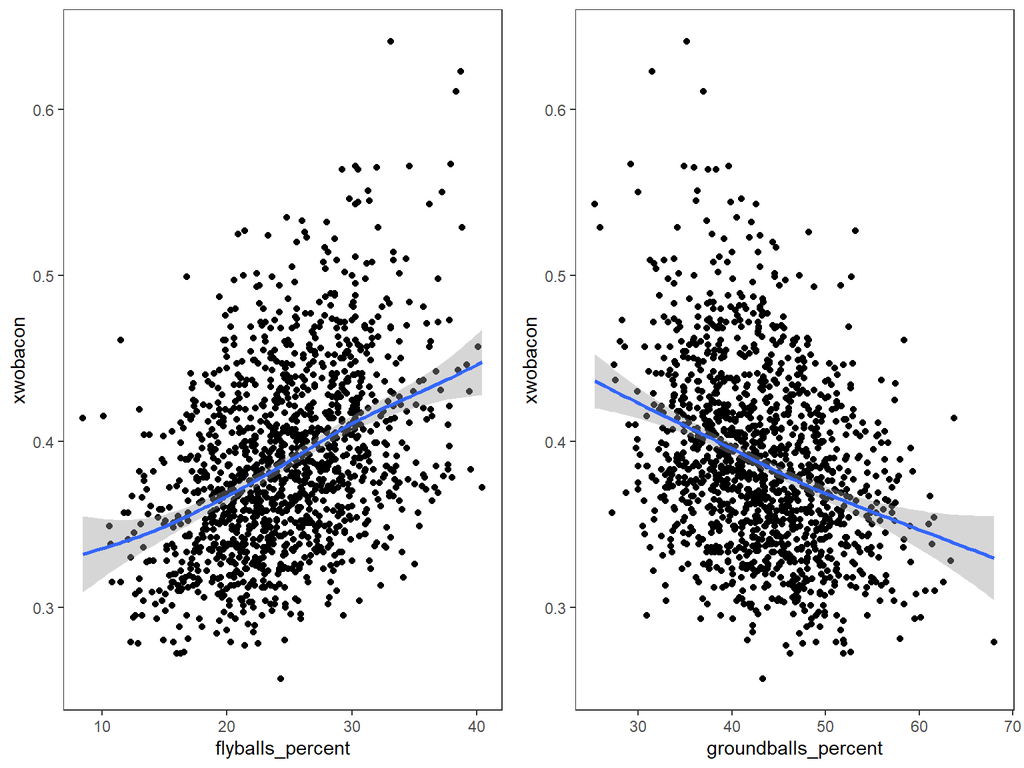

# Launch Angle

Launch angle refers to how high or low a ball was hit in degrees.

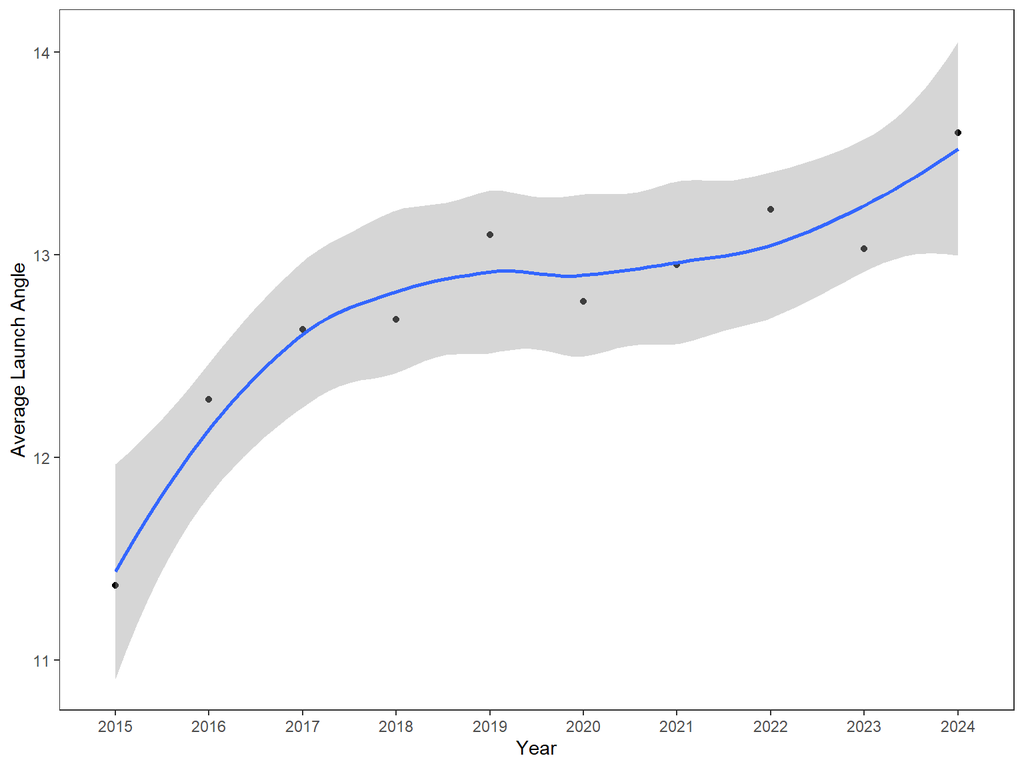

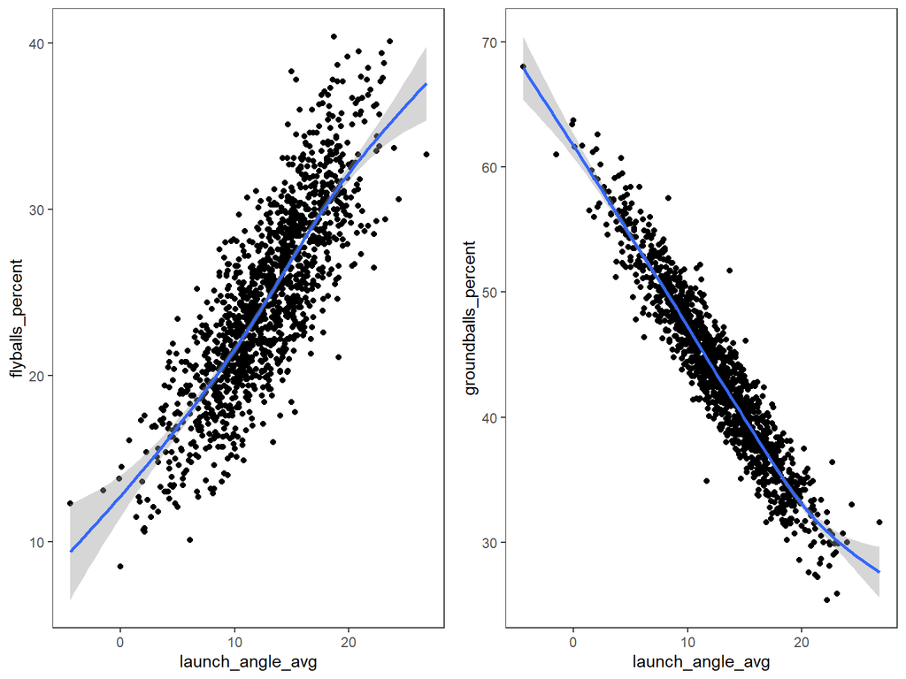

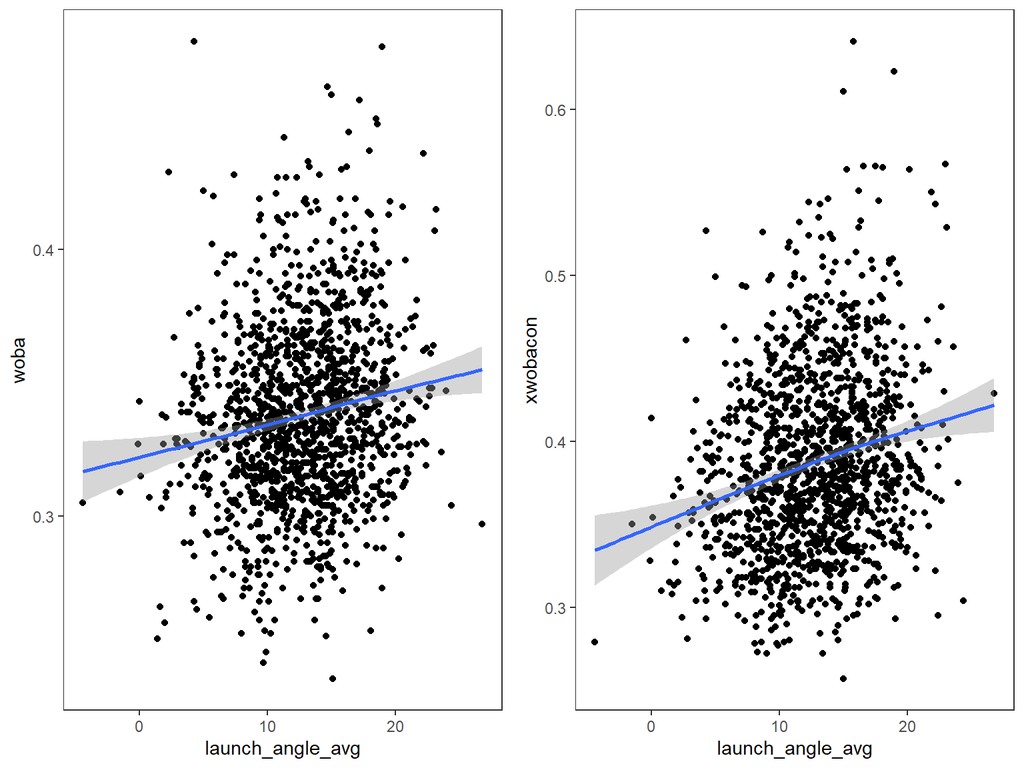

# Exit Velocity

Exit Velocity stands for the speed in Mph a ball was hit by a batter.

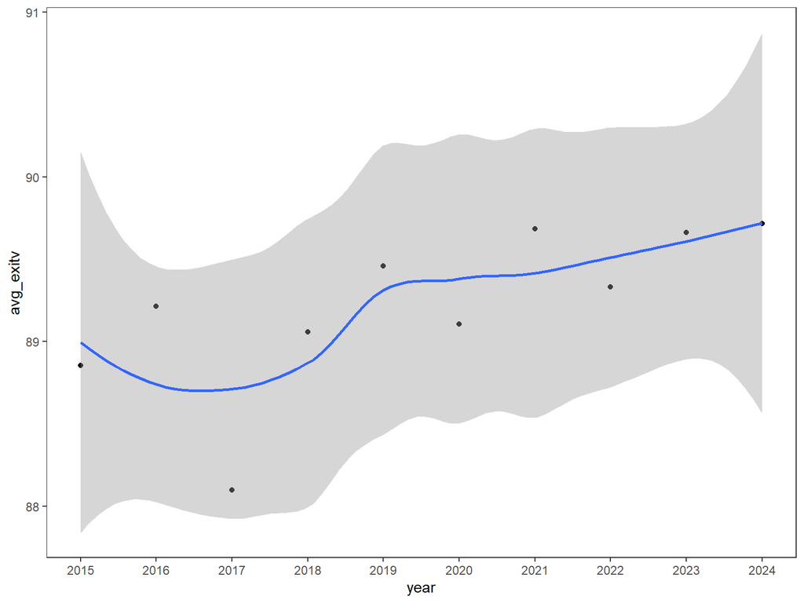

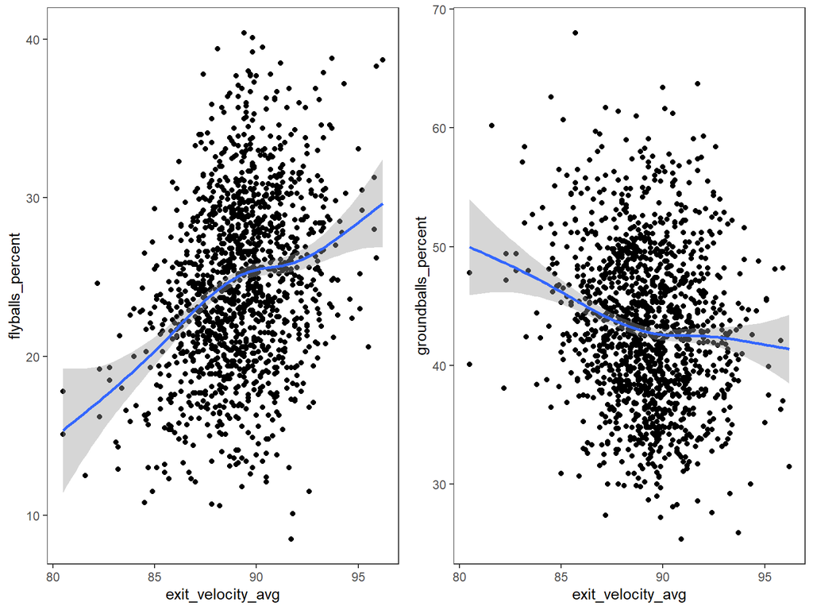

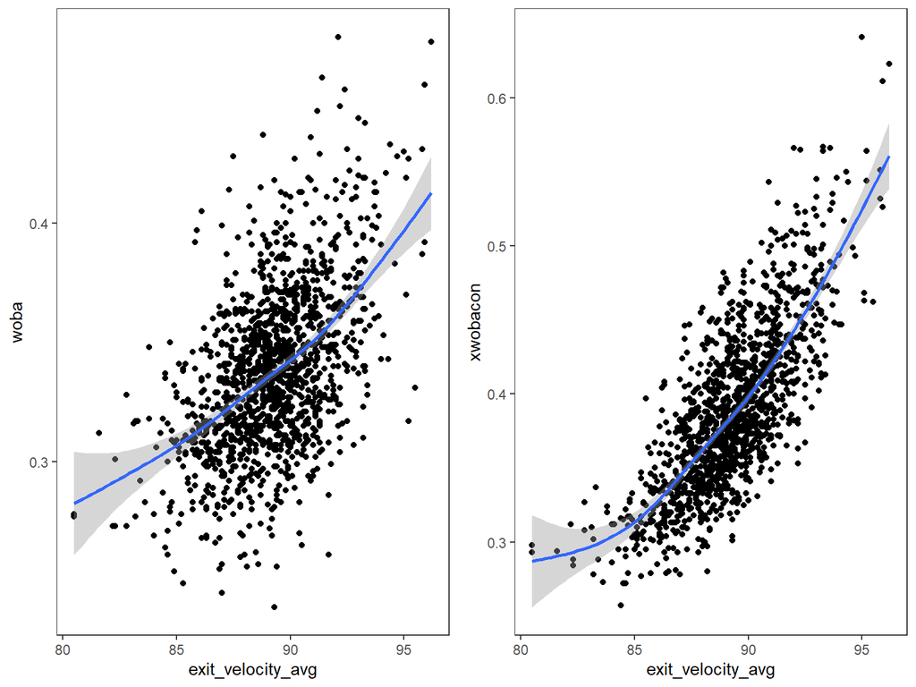

# Variables of interest (pitching)

- fast ball average velocity (`ff_avg_speed`)
- fast ball spin (`ff_avg_spin`)
- strikeout percentage (`k_percent`)
- weighted on base average (`woba`)

# The Importance of the Fast-Ball

The fast-ball is a pitcher’s most used pitch, and as such, we decided to focus on the effects Statcast has had on the fast-ball.

[figure not shown]

Pitch Mix from 2008 to 2023

[Fangraphs](https://blogs.fangraphs.com/a-league-wide-update-on-pitch-mix/)

# The Importance of Strikeouts and the Correlation of Fast-ball Quality in to Strikout Percentage

Strikeouts are important to a pitchers plan to limit runs and as such, they work towards increasing their strikeout percentage in an effort to succeed.

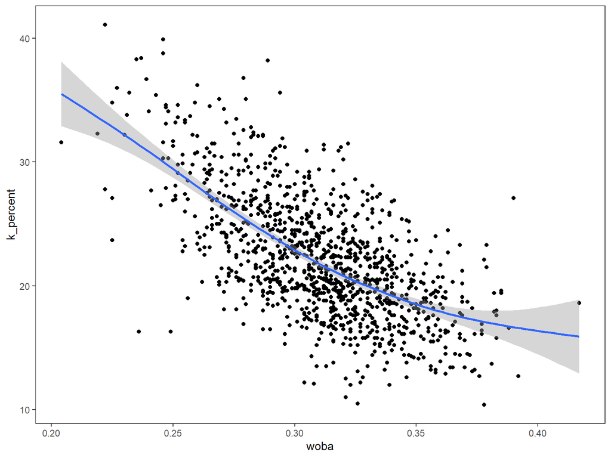

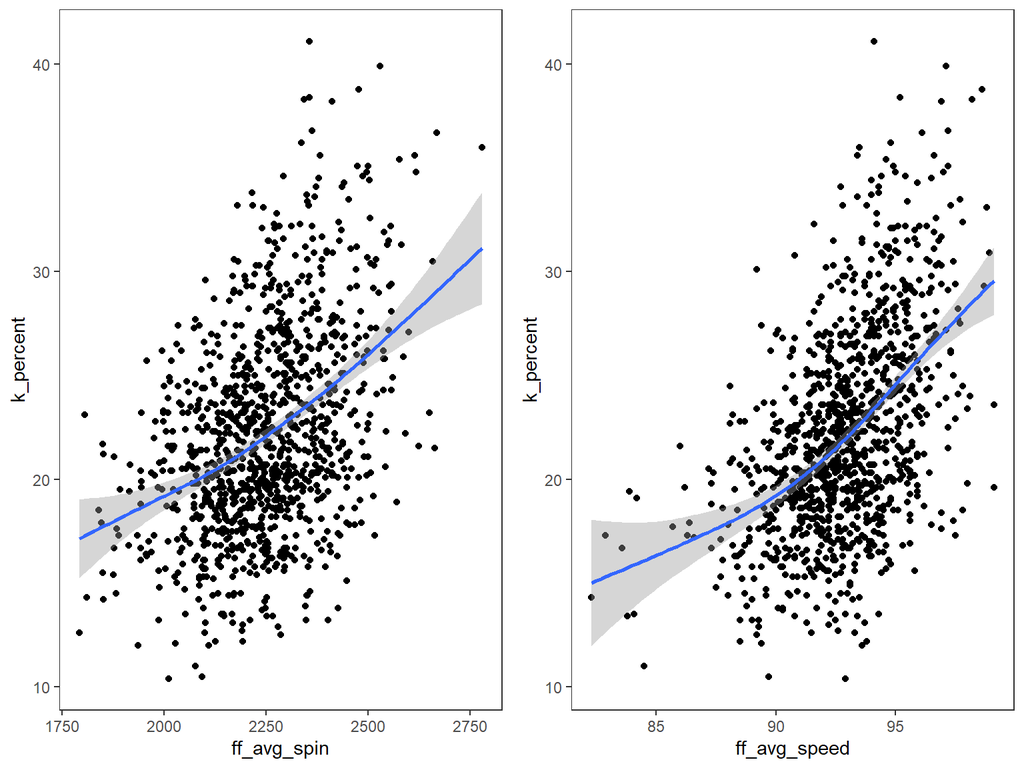

# The Correlation Between Fast-ball quality and woba

Given that a higher strikeout percentage correlates to a lower woba, having a quality Fast-ball to increase strikeout percentage decreases the woba.

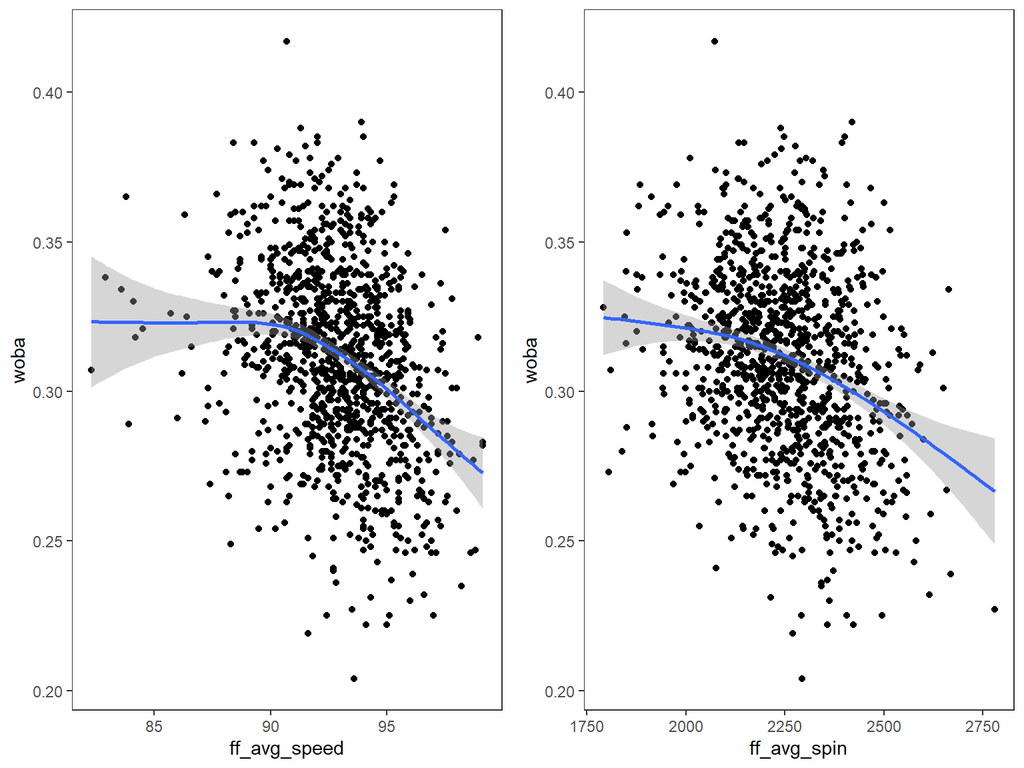

# How Pitchers Illegally Increased Their Spin Rate

Pitchers have always utilized foreign substances to put onto the baseball to get an advantage. However, with the introduction of spin rate, pitchers were able to more effectively optimize their ability to cheat.

Pitchers utilized resin-based Spider Tack to illegally increase their spin rate

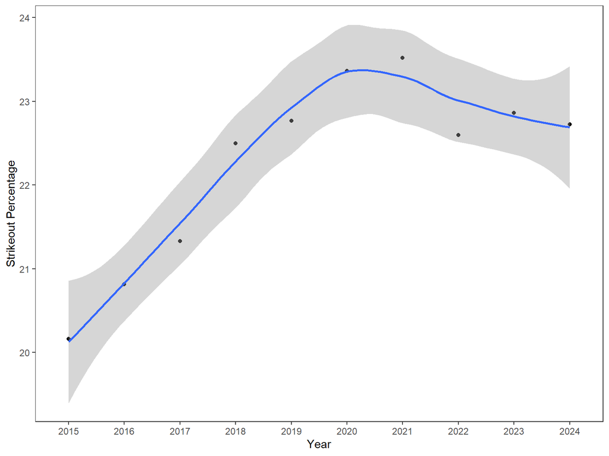

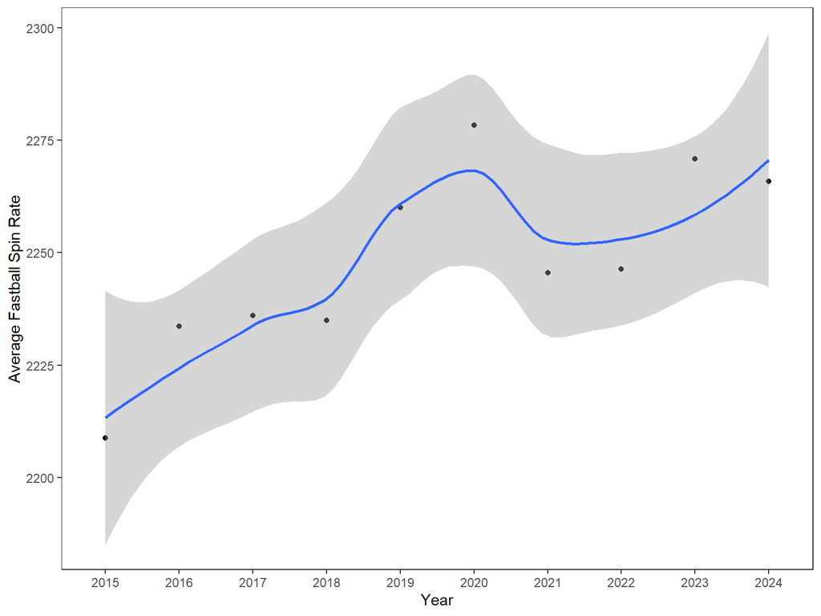

# Boxplots of strikeout percent by year

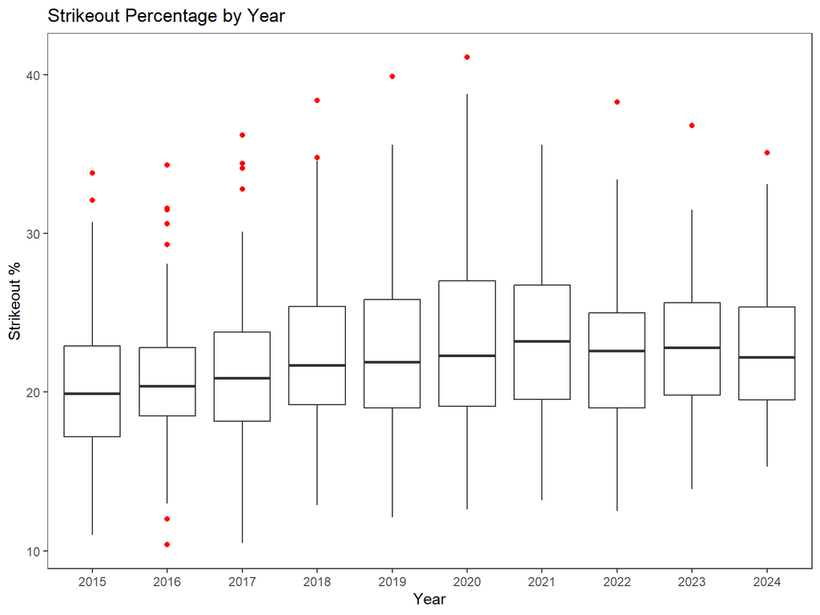

# Average strikeout by Year Trend Line

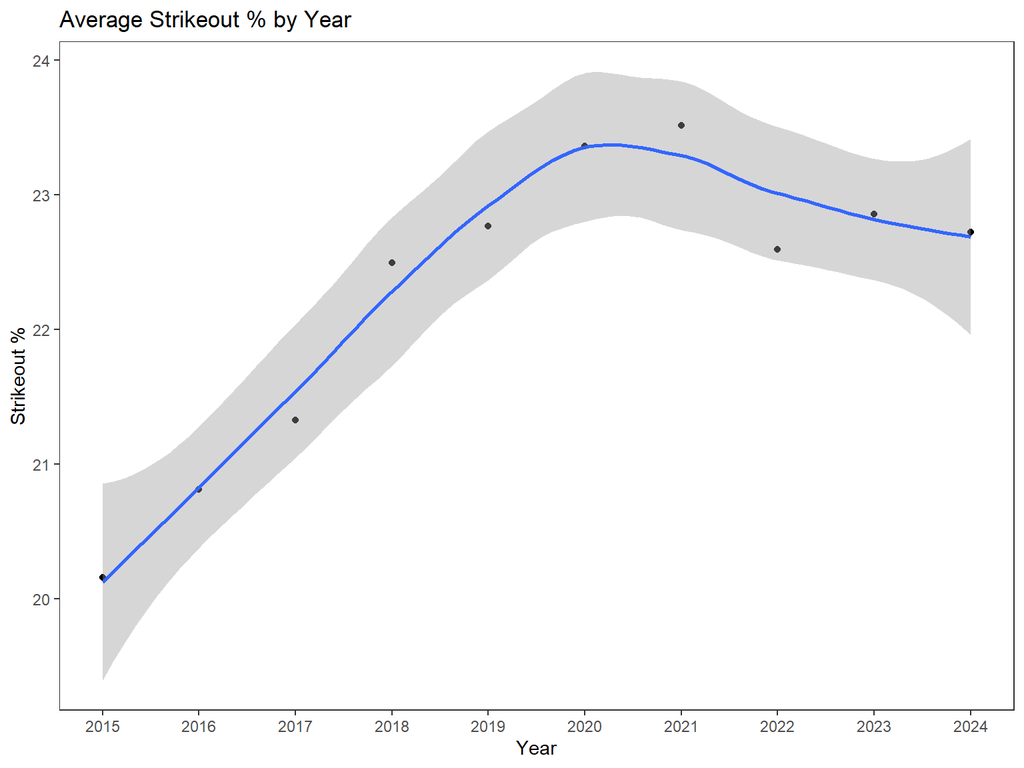

# A graph of the boxplots for hard hitting percentage by year

- Layered on top (purple dots) is the **average** hard hit percentage for each year.

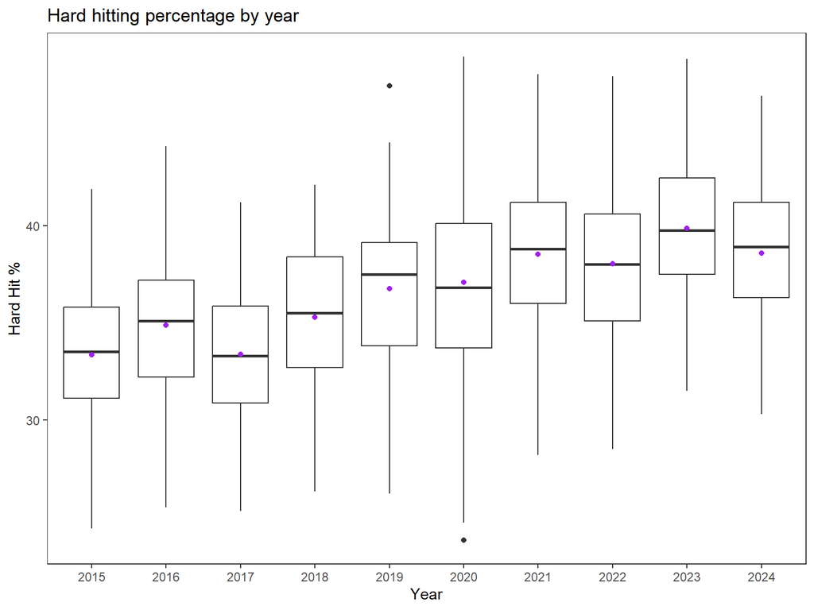

# Zooming in to *just* the average hard hit percent for each year, we can see a clearer correlation.

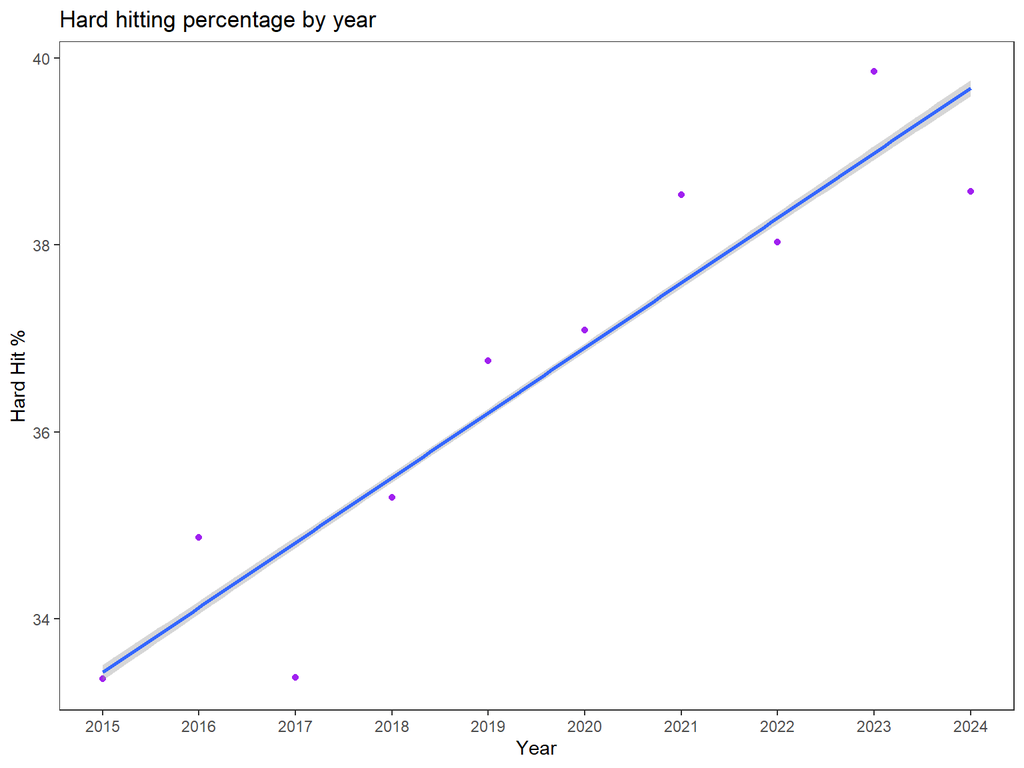

# A violin graph of this data.

- We continue to see the upward trend in hard hit percentage
- What’s with the elongated violin in 2020? As sample size decreases, standard deviation increases!

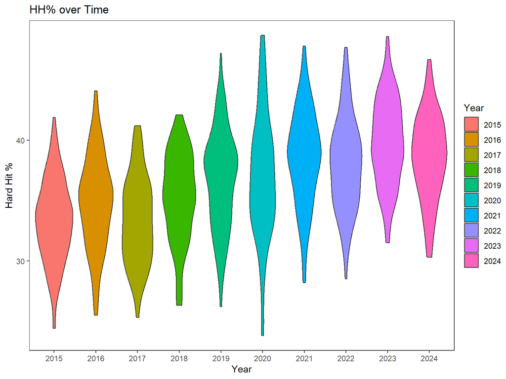

# What is this correlation and how significant is it?

- By conducting a linear regression model, on this data, we see:

```
##
## Call:
## lm(formula = hard_hit_percent ~ year, data = hitting)
##
## Residuals:
##     Min      1Q  Median      3Q     Max
## -29.630  -4.425   0.428   4.878  22.575
##
## Coefficients:
##               Estimate Std. Error t value Pr(>|t|)
## (Intercept) -1.470e+03  1.415e+02  -10.39   <2e-16 ***
## year         7.473e-01  7.005e-02   10.67   <2e-16 ***
## ---
## Signif. codes:  0 '***' 0.001 '**' 0.01 '*' 0.05 '.' 0.1 ' ' 1
##
## Residual standard error: 7.446 on 1373 degrees of freedom
## Multiple R-squared:  0.07655,    Adjusted R-squared:  0.07587
## F-statistic: 113.8 on 1 and 1373 DF,  p-value: < 2.2e-16
```

- According to the model, hard hit percentage increased on average .75% per year.
- This increase is associated with a very low p-value, indicating it is significant.

# Limitations

Limitations from the Statcast data set that we utilized is that it doesn’t include bat-tracking data as it was only launched in the middle of 2023 and does not retroactively track for previous years.

Futhermore, this Statcast data only includes qualified hitters in MLB and not in MiLB, NPB, KBO, or any other baseball leagues.

# Conclusion

In conclusion, Statcast has changed the way the game of baseball is played, analyzed, and optimized through hitters optimizing Launch Angles, Exit Velocities, upon much more while pitchers focus more on Strikeout percentages, Fast-ball speed,& spin while using whatever possible to get an advantage.